# Predicting Students’ Chance of Admission Using Beta Regression

Author

Marcus Chery and Keiron Green

Published

December 4, 2023

## Introduction

The beta distribution is characterized by two parameters: alpha (α) and beta (β). These parameters can be modeled as a function of predictor variables, allowing for the analysis of how independent variables influence the shape of the distribution.

Like logistic regression, beta regression often uses a link function to relate the mean of the beta distribution to the linear combination of predictor variables. Common link functions include logit, probit, and log-log. The coefficients obtained from beta regression provide insights into how changes in the predictor variables affect the distribution of the response variable, including its mean and variability.

## Methods

Another formula which will need to be accounted for in predicting the proportionality values is the beta density.The beta density is especially useful in modelling probabilities as it works on the interval [0,1] When implementing beta regression it is assumed that the response variable follows a beta distribution hence the name beta regression.

The beta density formula is below.
$$f(x;\alpha,\beta) =\frac{ \Gamma(p + q)}{\Gamma(p)*\Gamma(q)}x^{p-1}(1-x)^{q-1}$$
,
$$0 < y < 1$$
where $p,q$ > 0 and $\Gamma (.)$ is the Gamma function. An alternate parameterization was proposed by (Ferrari and Cribari-Neto 2004) by setting $u = p/(p+q)$ and $\phi = p + q$

$$f(y;\mu,\phi)=\frac{\Gamma(\phi)}{\Gamma(\mu\phi)\Gamma((1-\mu)\phi)} y^{\mu\phi-1}(1-y)^{(1-\mu)(\phi-1)}$$

$$0<y<1$$

with $0 < u < 1$ and $\phi > 0$.

We denote $y\sim B(u,\phi)$ where $E(y)=u$ and $VAR(y)=u(1-u)/(1+\phi)$. The $\phi$ is known as the precision parameter. For a fixed value of $u$ as the $\phi$ increases the variance of the response variable $y$ decreases.

Let $y_1,.....,y_n$ be a random sample set given that $y_i(u_i,), i = 1,……,n. The beta regression model is defined as
$$g(u_i) = x^T_iB = n_i$$
where $B=(B_1,....,B_k)$ is a $k*1$ vector of unknown regression parameters $(k<n),x_i=(x_i,......x_n)^T$ is the vector of k regressors(independent variables or covariates) and $n_i$ is a linear predictor - i.e.,$n_i = B_1x_{i1}+...+B_kx_{ik};$ usually $x_{i1}$ = 1 for all $i$ so that the model has an intercept.The $g(.): (0,1) -> IR$ represent the link function.

## Analysis and Results

This section aims to identify key variables for constructing a beta regression model to predict admission chances. Initially, we analyze the dataset to determine the correlation between various predictors and the chance of admission. Following this, we use these insights to develop and evaluate several models, focusing on their predictive accuracy and effectiveness. This process is critical for establishing a reliable model that accurately forecasts admission probabilities based on the identified significant predictors.

### Data and Visualization

Data: [**University Admission Data**](https://www.kaggle.com/datasets/akshaydattatraykhare/data-for-admission-in-the-university/data)

### Attribute Information

| Variable | Parameter | Range | Description |
| --- | --- | --- | --- |
| GRE Scores | gre_score | 290 - 340 (340 scale) | Quantifies a candidate’s performance on the Graduate Record Examination with a maximum score of 340. |
| TOEFL Scores | toefl_score | 92 - 120 ( 120 scale) | Measure English Language Proficiency |
| University Rating | university_rating | 1 to 5 with 5 being. highest rating. | Rates universities on a of 1 to 5, indicating their overall quality and reputation |
| State of Purpose | sop | 1 to 5 with 5 being highest rating | Evaluates the strength and quality of a candidate’s SOP on a scale of 1 to 5. |
| Letter of Recomm endation(LOR). Strength. | lor | 1 to 5 with 5 being highest rating | Evaluates the strength and quality of a candidate’s LOR on a scale of 1 to 5. |
| Undergraduate G.P.A | cgpa | 6.8 to 9.92 (10 scale) | Reflects a student’s academic performance in their undergraduate schooling which is scored on a 10.0 point scale |
| Research Experience | research | 0 or 1 | Indicates whether a candidate has research experience (1) or not(0) |
| Chance of admit | chance_of_admit | 0.34 to 0.97 scale (0 to 1) | Represents the likelihood of a student being admitted,expressed as a decimal between 0 and 1 |

### Libraries

Load necessary packages for analysis and modeling.

```r
#install.packages("janitor")
#install.packages("caTools")
#Insatll required packages
#install.packages('caret')
library(caret)
library(reshape2)
library(tidyverse)
library(ggplot2)
library(readr)
library(dplyr)
library(betareg)
library(lmtest)
library(car)
library(rcompanion)
library(janitor)
library(here)
library(caTools)
library(pROC)
```

### Loading Dataset

```r
admission <- read_csv("adm_data.csv")
#str(admission)

admission <- admission %>%
  clean_names()

head(admission,5)
```

```
# A tibble: 5 × 9
  serial_no gre_score toefl_score university_rating   sop   lor  cgpa research
      <dbl>     <dbl>       <dbl>             <dbl> <dbl> <dbl> <dbl>    <dbl>
1         1       337         118                 4   4.5   4.5  9.65        1
2         2       324         107                 4   4     4.5  8.87        1
3         3       316         104                 3   3     3.5  8           1
4         4       322         110                 3   3.5   2.5  8.67        1
5         5       314         103                 2   2     3    8.21        0
# ℹ 1 more variable: chance_of_admit <dbl>
```

# Model Assumptions

Assumptions

Descriptions

Assumptions Met

Beta distribution of dependent variable

The dependent variable is continuous and bounded between 0 and 1

```
  Met
```

Independent Observations

Oberservation independent of each other

```
  Assumed
```

Homoscedasticity of Error Terms

The variance of error terms are constant across levels of independent variables

```
  Assumed
```

Linearity of Predictors

There are linear relationship between logit of the expected value and predictors

```
  Met
```

No Perfect Multi collinearity

Predictors are not perfectly collinear

```
  Met
```

No Outliers

The data does not have . influential outliers.

```
  Met
```

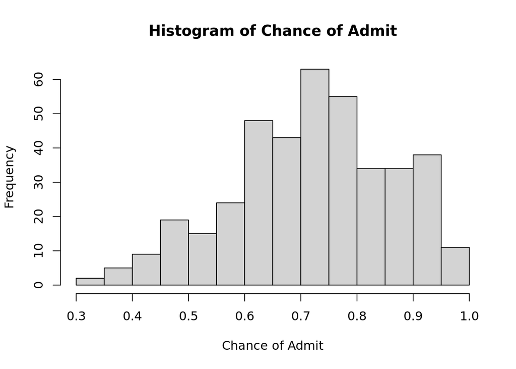

```r
hist(admission$chance_of_admit, breaks=20, main="Histogram of Chance of Admit", xlab="Chance of Admit")
```

#### The dependent variable is continuous and bounded between 0 and 1.

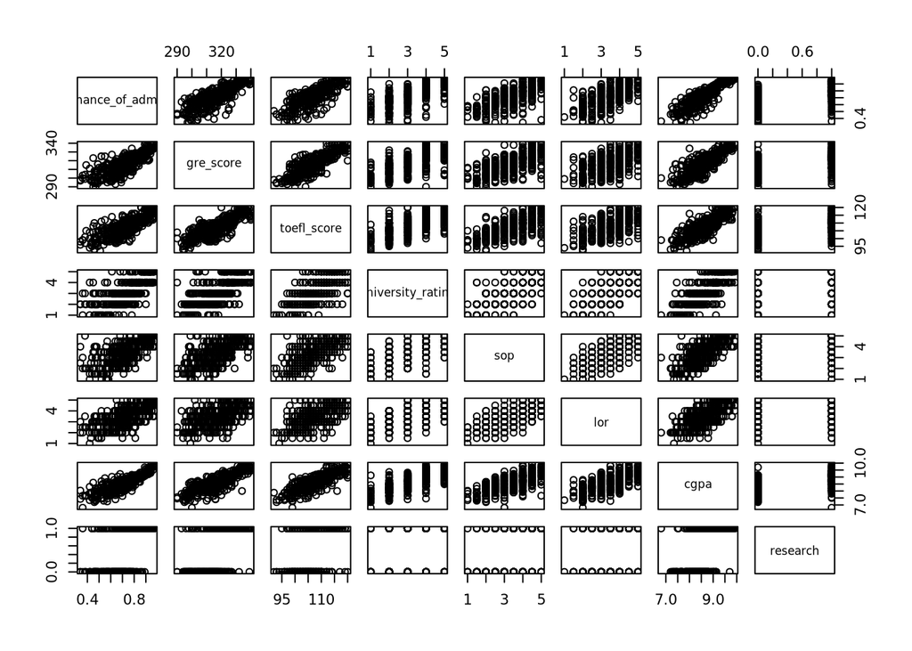

```r
pairs(~ chance_of_admit + gre_score + toefl_score + university_rating + sop + lor + cgpa + research, data = admission)
```

#### There are linear relationship between logit of the expected value and predictors.

```r
library(car)
vif(lm(chance_of_admit ~ gre_score + toefl_score + university_rating + sop + lor + cgpa + research, data = admission))
```

```
        gre_score       toefl_score university_rating               sop
         4.615516          4.288959          2.919606          3.075504
              lor              cgpa          research
         2.431258          5.207403          1.543312
```

#### VIF scores are not greater than the chosen threshold of 10

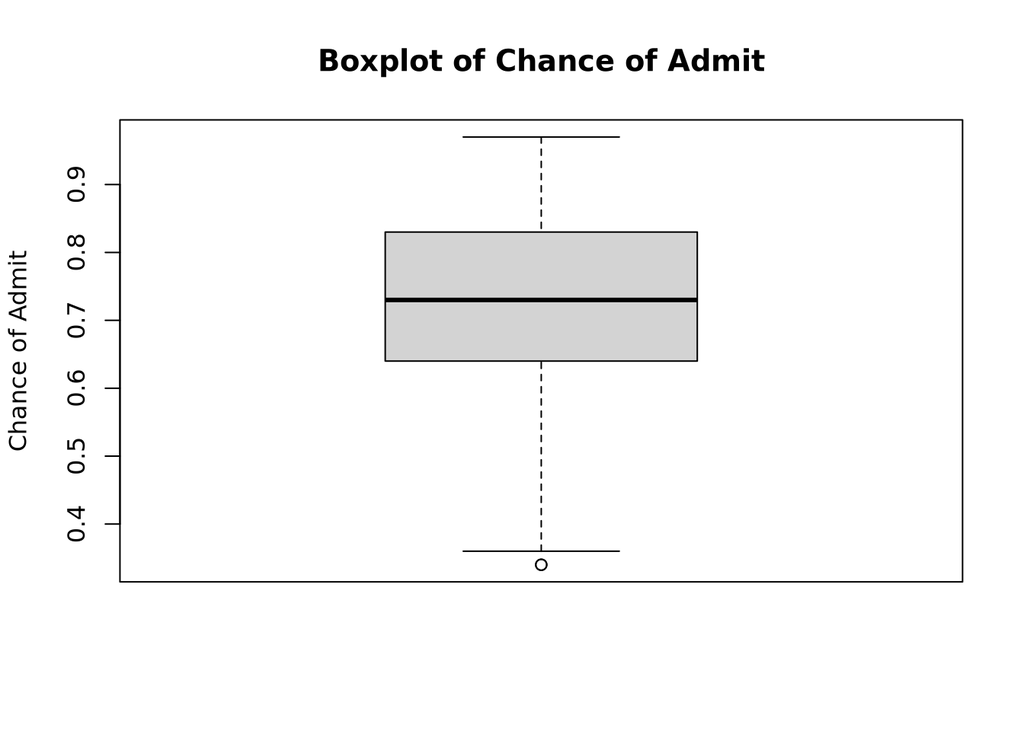

```r
boxplot(admission$chance_of_admit, main = "Boxplot of Chance of Admit", ylab = "Chance of Admit")
```

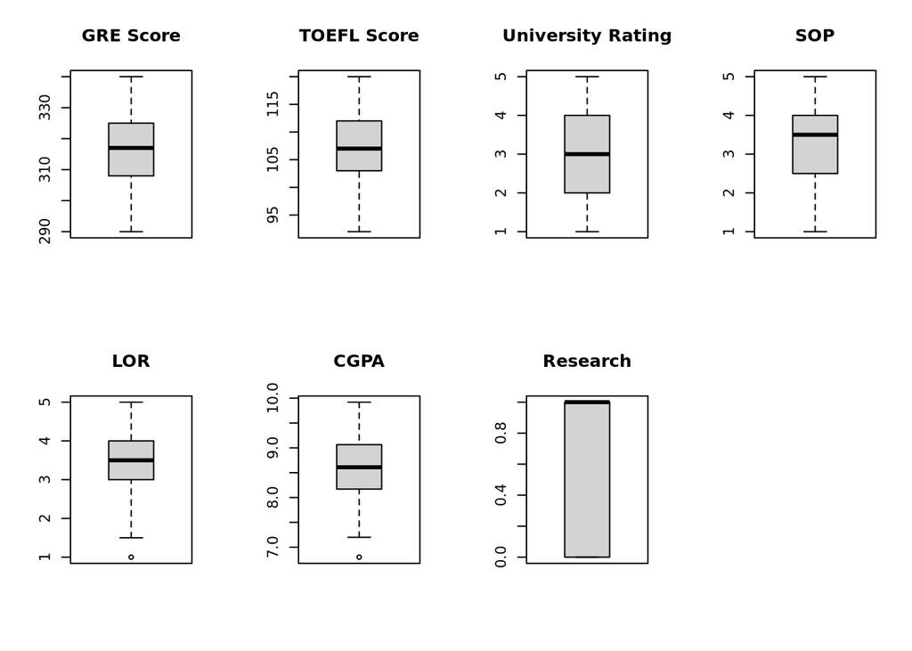

```r
par(mfrow = c(2, 4))  # Adjust layout to display multiple plots
boxplot(admission$gre_score, main = "GRE Score")
boxplot(admission$toefl_score, main = "TOEFL Score")
boxplot(admission$university_rating, main = "University Rating")
boxplot(admission$sop, main = "SOP")
boxplot(admission$lor, main = "LOR")
boxplot(admission$cgpa, main = "CGPA")
boxplot(admission$research, main = "Research")
```

#### The data does not have influential outliers

## Further EDA

### Chance of Admit and TOEFL

Based on exploratory data analysis, TOEFL scores appear to be associated with a greater chance of admission, this chance of admission is further augmented by higher university ratings, and research experience appears to be a strong factor in increasing both TOEFL scores and the likelihood of admission.

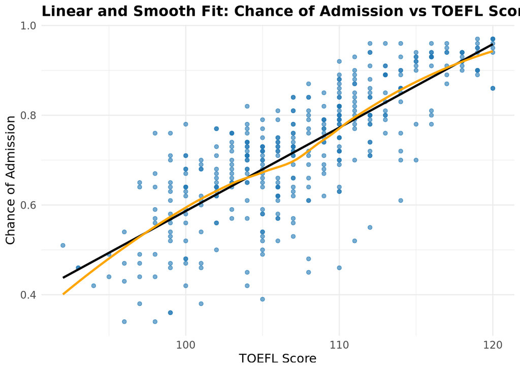

```r
ggplot(admission, aes(x = toefl_score, y = chance_of_admit)) +
  geom_point(color = "#1f77b4", alpha = 0.6) +
  geom_smooth(method = "lm", color = "black", se = FALSE) +
  geom_smooth(method = "loess", color = "orange", se = FALSE) +
  labs(x = "TOEFL Score", y = "Chance of Admission", title = "Linear and Smooth Fit: Chance of Admission vs TOEFL Score") +
  theme_minimal() +
  theme(plot.title = element_text(color = "black", size = 14, face = "bold"),
        axis.title = element_text(size = 12),
        axis.text = element_text(size = 10),
        legend.position = "bottom")
```

The correlation coefficient of 0.791594 between TOEFL scores and the chance of admit suggests a strong positive relationship. This indicates that as TOEFL scores increase, the chance of admission tends to increase as well.

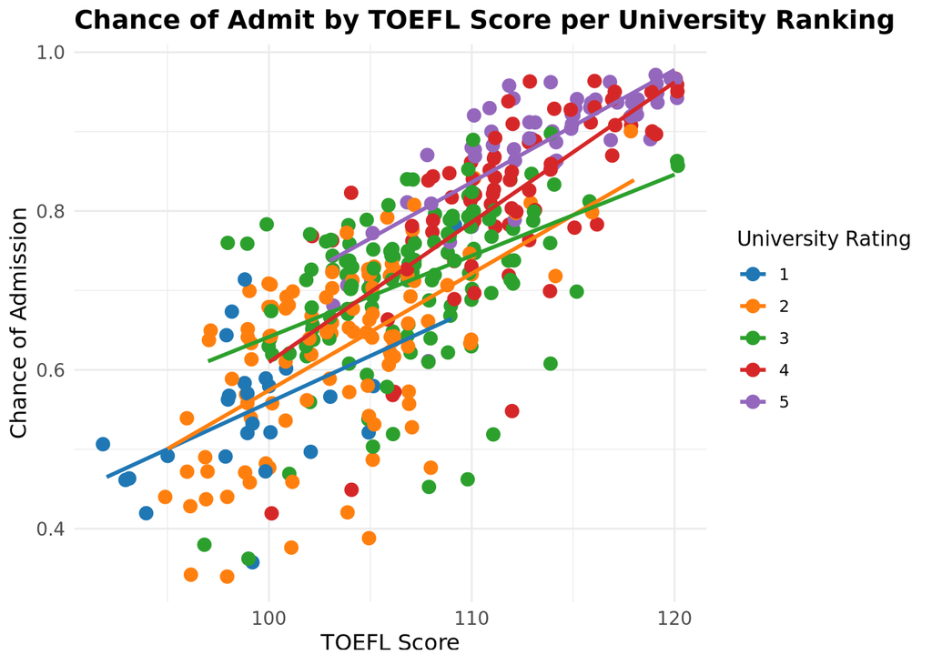

```r
ggplot(admission, aes(x = toefl_score, y = chance_of_admit, color = as.factor(university_rating))) +
  geom_jitter(width = .2, size = I(3)) +
  scale_color_manual(values = c("#1f77b4", "#ff7f0e", "#2ca02c", "#d62728", "#9467bd")) +
  labs(x = "TOEFL Score", y = "Chance of Admission", color = "University Rating",
       title = "Chance of Admit by TOEFL Score per University Ranking") +
  theme_minimal() +
  theme(plot.title = element_text(color = "black", size = 14, face = "bold"),
        axis.title = element_text(size = 12),
        axis.text = element_text(size = 10)) +
  geom_smooth(method = "lm", se = FALSE)
```

This trend indicates that applicants to higher-rated universities generally have a higher chance of admission. The standard deviation decreases as the university rating increases, suggesting more consistency in admission chances at higher-rated universities.

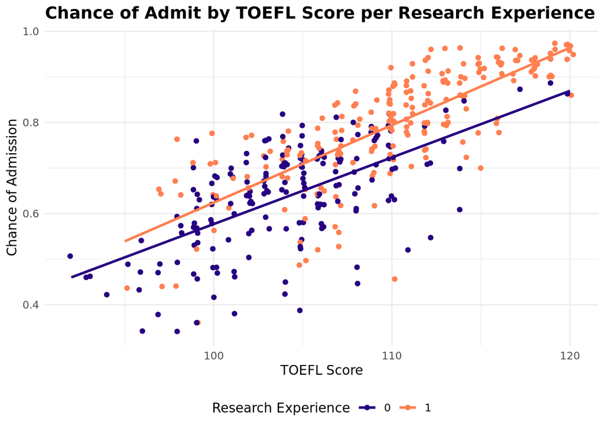

```r
ggplot(admission, aes(x = toefl_score, y = chance_of_admit, color = as.factor(research))) +
  geom_jitter(width = .2) +
  scale_color_manual(values = c("#270181", "coral")) +
  labs(x = "TOEFL Score", y = "Chance of Admission", color = "Research Experience",
       title = "Chance of Admit by TOEFL Score per Research Experience") +
  theme_minimal() +
  theme(plot.title = element_text(color = "black", size = 14, face = "bold"),
        legend.position = "bottom") +
  geom_smooth(method = "lm", se = FALSE)
```

Applicants with research experience (Research = 1) have a higher average TOEFL score (approx. 110) compared to those without research experience (Research = 0), who have an average TOEFL score of about 104.

The mean chance of admission for applicants with research experience is significantly higher (approx. 0.796) than for those without (approx. 0.638).

This data suggests that research experience is positively associated with both higher TOEFL scores and a greater likelihood of admission.

### Chance of Admit and GRE

These analyses suggest that higher GRE scores are strongly correlated with an increased chance of admission. The likelihood of admission also appears to be influenced by the university rating and is further enhanced by research experience.

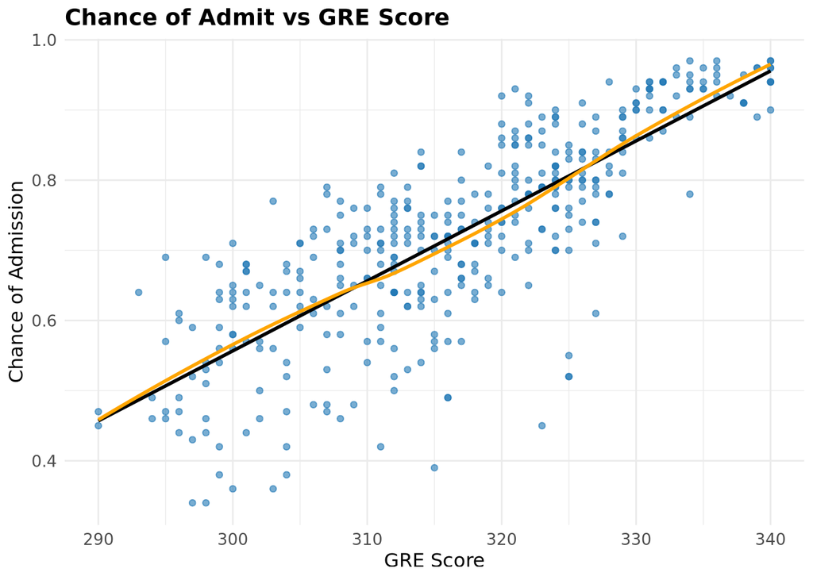

```r
library(ggplot2)

ggplot(admission, aes(x = gre_score, y = chance_of_admit)) +
  geom_point(color = "#1f77b4", alpha = 0.6) +
  geom_smooth(method = "lm", color = "black", se = FALSE) +
  geom_smooth(method = "loess", color = "orange", se = FALSE) +
  labs(x = "GRE Score", y = "Chance of Admission",
       title = "Chance of Admit vs GRE Score") +
  theme_minimal() +
  theme(plot.title = element_text(color = "black", size = 14, face = "bold"),
        axis.title = element_text(size = 12),
        axis.text = element_text(size = 10),
        legend.position = "bottom") +
  guides(color = guide_legend(title = "Type of Fit",
                              override.aes = list(linetype = c("solid", "dashed"))))
```

A correlation coefficient of 0.8026105 indicates a strong positive relationship between GRE scores and the chance of admission. This suggests that higher GRE scores are generally associated with a higher likelihood of being admitted.

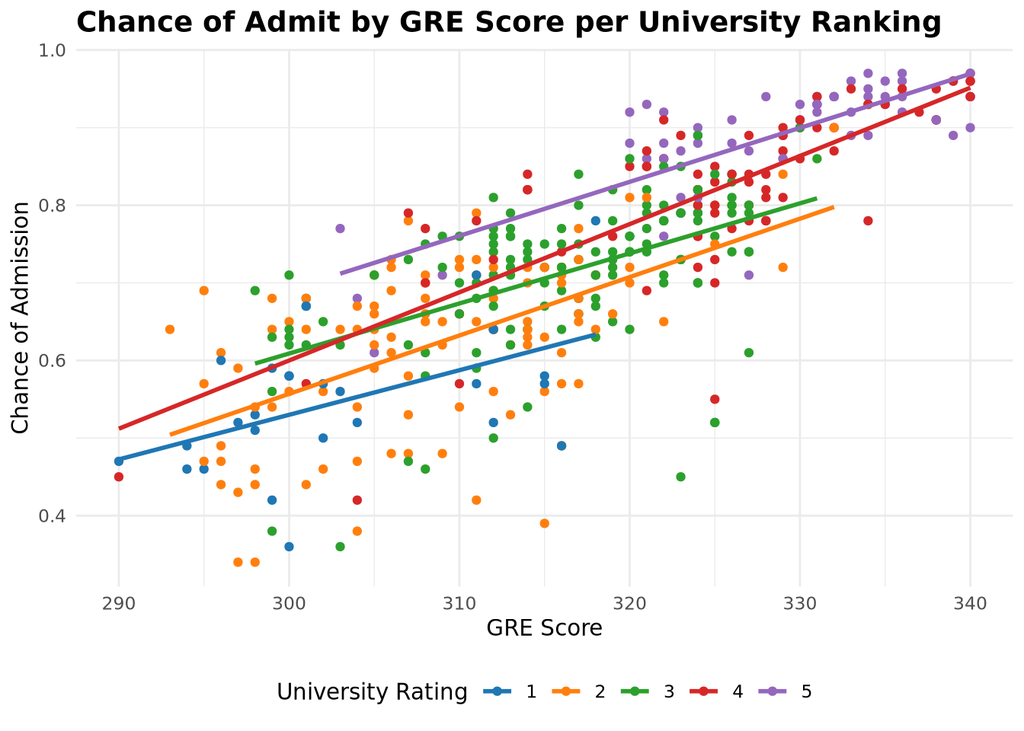

```r
ggplot(admission, aes(x = gre_score, y = chance_of_admit, color = as.factor(university_rating))) +
  geom_point() +
  scale_color_manual(values = c("#1f77b4", "#ff7f0e", "#2ca02c", "#d62728", "#9467bd")) +
  labs(x = "GRE Score", y = "Chance of Admission", color = "University Rating",
       title = "Chance of Admit by GRE Score per University Ranking") +
  theme_minimal() +
  theme(plot.title = element_text(color = "black", size = 14, face = "bold"),
        legend.position = "bottom") +
  geom_smooth(method = "lm", se = FALSE)
```

This trend suggests that applicants to higher-rated universities have a higher chance of admission, with the chance of admission being most favorable at the highest-rated universities.

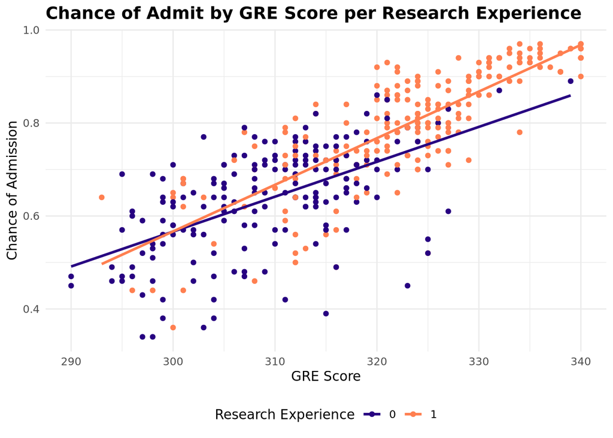

```r
ggplot(admission, aes(x = gre_score, y = chance_of_admit, color = as.factor(research))) +
  geom_point() +
  scale_color_manual(values = c("#270181", "coral")) +
  labs(x = "GRE Score", y = "Chance of Admission", color = "Research Experience",
       title = "Chance of Admit by GRE Score per Research Experience") +
  theme_minimal() +
  theme(plot.title = element_text(color = "black", size = 14, face = "bold"),
        legend.position = "bottom") +
  geom_smooth(method = "lm", se = FALSE)
```

Applicants with research experience (Research = 1) have a higher average GRE score (about 323) compared to those without research experience (Research = 0), who have an average GRE score of approximately 309. Similarly, the mean chance of admission is significantly higher for applicants with research experience (approx. 0.796) than for those without it (approx. 0.638). This indicates that research experience is positively associated with both higher GRE scores and a greater likelihood of admission.

### Chance of Admit and CGPA

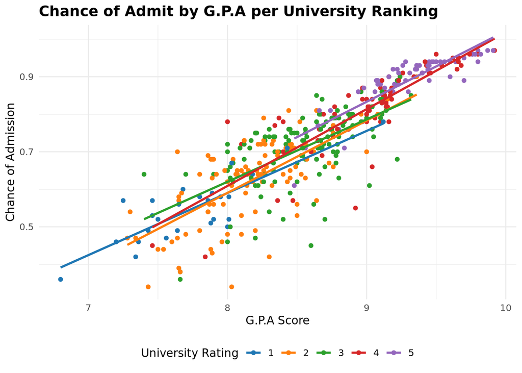

```r
ggplot(admission, aes(x = cgpa, y = chance_of_admit, color = as.factor(university_rating))) +
  geom_point() +
  scale_color_manual(values = c("#1f77b4", "#ff7f0e", "#2ca02c", "#d62728", "#9467bd")) +
  labs(x = "G.P.A Score", y = "Chance of Admission", color = "University Rating",
       title = "Chance of Admit by G.P.A per University Ranking") +
  theme_minimal() +
  theme(plot.title = element_text(color = "black", size = 14, face = "bold"),
        legend.position = "bottom") +
  geom_smooth(method = "lm", se = FALSE)
```

Applicants with a higher g.p.a have a higher acceptance probability as the university ranking goes from low(1) to high(5). The correlation value of 0.87 indicates a strong positive relationship between G.P.A score and the chance of admission. This suggests that higher a G.P.A score are generally associated with a higher likelihood of being admitted.

### Chance of Admission Correlation Heatmap

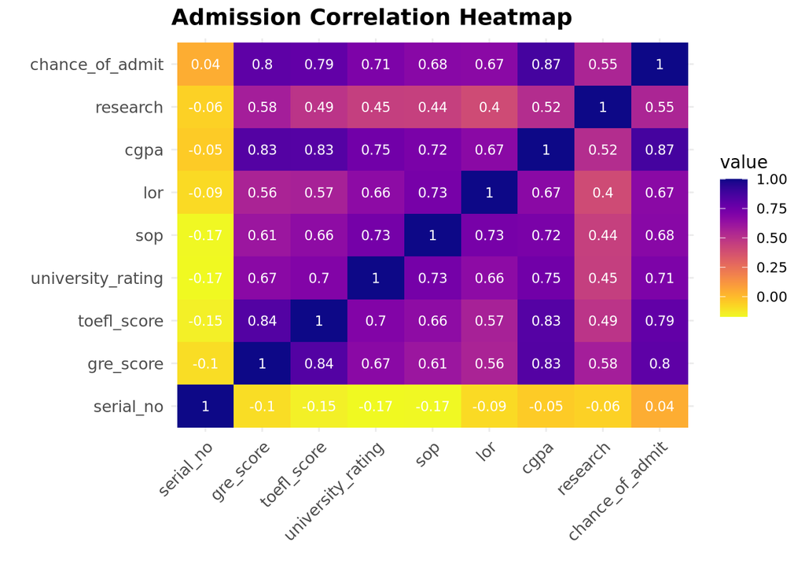

```r
library(ggplot2)
library(reshape2)
library(viridis)

# Calculate the correlation matrix
data <- cor(admission[sapply(admission, is.numeric)], use = "complete.obs")

# Reshape data for ggplot
data1 <- melt(data)

# Create the heatmap
ggplot(data1, aes(x = Var1, y = Var2, fill = value)) +
  geom_tile() +
  scale_fill_viridis(option = "C", direction = -1) +  # Using viridis color scale
  labs(title = "Admission Correlation Heatmap", x = "", y = "") +
  theme_minimal() +
  theme(axis.text.x = element_text(angle = 45, vjust = 1, hjust = 1, size = 10),
        axis.text.y = element_text(size = 10),
        plot.title = element_text(color = "black", size = 14, face = "bold"),
        legend.position = "right") +
  geom_text(aes(label = round(value, digits = 2)), color = "white", size = 3)
```

The heatmap shows that GRE scores, TOEFL scores, and CGPA are strongly and positively correlated with the chance of admission. Research experience also positively influences admission chances, albeit to a lesser extent than academic scores.

## Analysis and Results

Given the exploratory data analysis, we will now construct a predictive model for the response variable chance_of_admit.

```r
# Scaling of Data
#admission <- scale(admission)
#admission <- as.data.frame(admission)
```

```r
# Splitting the Data

#make this example reproducible
set.seed(1)

#Use 70% of dataset as training set and remaining 30% as testing set
sample <- sample(c(TRUE, FALSE), nrow(admission), replace=TRUE, prob=c(0.7,0.3))
train  <- admission[sample, ]
test   <- admission[!sample, ]

#view dimensions of training set
#dim(train)

#view dimensions of test set
#dim(test)

X_train <- train

X_test = subset(test,select = -c(chance_of_admit))
keeps <- c("chance_of_admit")
y_test = test[keeps]
```

## Fitting Model 1

Model 1 = chance_of_admit ~ gre_score + toefl_score + university_rating + sop + lor + cgpa + research + sop*lor

```r
gy_logit <- betareg(chance_of_admit ~ gre_score + toefl_score + university_rating + sop + lor + cgpa + research + sop*lor, data = train)

model_summary <- summary(gy_logit)
# Extracting coefficients for the mean model
coefficients_mean <- model_summary$coefficients$mean
coeff_mean_df <- data.frame(round(coefficients_mean, 4))
colnames(coeff_mean_df) <- c("Estimate", "Std. Error", "z value", "Pr(>|z|)")

# Extract log-likelihood and pseudo R-squared
log_likelihood <- round(model_summary$loglik, 2)
pseudo_r_squared <- round(model_summary$pseudo.r.squared, 4)

# Print the formatted results
print("Coefficients (Mean Model):")
```

```
[1] "Coefficients (Mean Model):"
```

```r
print(coeff_mean_df)
```

```
                  Estimate Std. Error  z value Pr(>|z|)
(Intercept)        -9.1585     0.7793 -11.7528   0.0000
gre_score           0.0087     0.0034   2.5672   0.0103
toefl_score         0.0209     0.0064   3.2752   0.0011
university_rating   0.0299     0.0299   1.0003   0.3172
sop                -0.2781     0.0733  -3.7949   0.0001
lor                -0.1030     0.0759  -1.3575   0.1746
cgpa                0.6348     0.0685   9.2616   0.0000
research            0.1516     0.0457   3.3205   0.0009
sop:lor             0.0716     0.0214   3.3503   0.0008
```

```r
cat("\nLog-Likelihood:", log_likelihood, "\nPseudo R-squared:", pseudo_r_squared)
```

```
Log-Likelihood: 414.39
Pseudo R-squared: 0.8379
```

Next we use the`regsubsets` function to perform subset selection, aiming to identify the most predictive variables for the `chance_of_admit` outcome. This approach systematically evaluates combinations of up to seven predictors, such as `gre_score`, `toefl_score`, `cgpa`, and others, to determine their impact on the chance of admission. The goal is to find the optimal set of variables that best predict the admission outcome with varying model complexities.

```r
library(leaps)
models <- regsubsets(chance_of_admit~. -serial_no, data = admission, nvmax = 9,
                     method = "seqrep")

library(broom)

model_summaries <- summary(models)

# Number of models
num_models <- nrow(model_summaries$which)

# Initialize an empty data frame for the summary
summary_table <- data.frame(Size = integer(),
                            Variables = character(),
                            R.Squared = numeric(),
                            Adj.R.Squared = numeric(),
                            BIC = numeric(),
                            stringsAsFactors = FALSE)

# Fill the summary table
for (i in 1:num_models) {
  included_vars <- names(which(model_summaries$which[i, ]))
  vars_str <- paste(included_vars, collapse = ", ")
  summary_table <- rbind(summary_table,
                         data.frame(Size = i,
                                    Variables = vars_str,
                                    R.Squared = model_summaries$rsq[i],
                                    Adj.R.Squared = model_summaries$adjr2[i],
                                    BIC = model_summaries$bic[i]))
}

# Print the table
print(summary_table)
```

```
  Size
1    1
2    2
3    3
4    4
5    5
6    6
7    7
                                                                         Variables
1                                                                (Intercept), cgpa
2                                              (Intercept), gre_score, toefl_score
3                                                (Intercept), gre_score, lor, cgpa
4                                      (Intercept), gre_score, lor, cgpa, research
5                 (Intercept), gre_score, toefl_score, university_rating, sop, lor
6           (Intercept), gre_score, toefl_score, university_rating, sop, lor, cgpa
7 (Intercept), gre_score, toefl_score, university_rating, sop, lor, cgpa, research
  R.Squared Adj.R.Squared       BIC
1 0.7626339     0.7620375 -563.2776
2 0.6925050     0.6909559 -453.7442
3 0.7941207     0.7925610 -608.2202
4 0.7986651     0.7966263 -611.1569
5 0.7504324     0.7472653 -519.2615
6 0.7987119     0.7956388 -599.2669
7 0.8034714     0.7999619 -602.8472
```

In this analysis 10-fold cross-validation is employed to provide assessment of the model’s predictive performance by dividing the data into ten subsets and iteratively training the model on nine subsets while testing on the remaining one. The procedure is repeated for models with varying numbers of predictors. Key performance metrics such as RMSE (Root Mean Squared Error), R-squared, and MAE (Mean Absolute Error) are calculated for each model, showing how the inclusion of additional variables impacts the model’s accuracy. The results show variations in model performance across different numbers of predictors, with certain models achieving lower RMSE and higher R-squared values

```r
# Set seed for reproducibility
set.seed(123)
# Set up repeated k-fold cross-validation
train.control <- trainControl(method = "cv", number = 10)
# Train the model
step.model <- train(chance_of_admit ~. -serial_no, data = admission,
                    method = "leapSeq",
                    tuneGrid = data.frame(nvmax = 1:7),
                    trControl = train.control
                    )
step.model$results
```

```
  nvmax       RMSE  Rsquared        MAE      RMSESD RsquaredSD       MAESD
1     1 0.06889355 0.7635275 0.05110306 0.009641911 0.06007377 0.007013934
2     2 0.07889825 0.6984116 0.06031014 0.013609817 0.06846210 0.010474096
3     3 0.06452847 0.7965067 0.04693197 0.009982503 0.05017603 0.007105953
4     4 0.06692766 0.7838953 0.04978752 0.015166549 0.06632972 0.012106201
5     5 0.06929365 0.7693051 0.05126744 0.008662209 0.05018380 0.005967808
6     6 0.06422188 0.7988891 0.04638031 0.010252374 0.05087166 0.007242793
7     7 0.06347942 0.8033827 0.04585758 0.010594007 0.05415636 0.007976196
```

We employ beta regression models to predict the chance of admission, utilizing various combinations of predictors such as GRE scores, TOEFL scores, university ratings, letters of recommendation, CGPA, and research experience. The primary objective is to determine the optimal set of predictors that can accurately forecast admission chances while maintaining model simplicity.

The models, labeled `gy_logit` to `gy_logit7`, were evaluated using the Akaike Information Criterion (AIC) and the pseudo R-squared metric. A lower AIC value indicates a more efficient model in terms of the trade-off between goodness of fit and complexity, while a higher pseudo R-squared value suggests a better model fit.

The outcomes reveal that `gy_logit4` and `gy_logit7` yield the lowest AIC values, indicating they are potentially the most efficient models among those tested. Both these models, along with `gy_logit`, also exhibit the highest pseudo R-squared values, suggesting strong model fits.

```r
gy_logit <- betareg(chance_of_admit ~ gre_score + toefl_score + university_rating + lor + cgpa + research, data = train)

gy_logit1 <- betareg(chance_of_admit ~ gre_score + toefl_score + university_rating + lor + cgpa , data = train)

gy_logit2 <- betareg(chance_of_admit ~ gre_score + toefl_score + university_rating + lor + research, data = train)

gy_logit3 <- betareg(chance_of_admit ~ gre_score + toefl_score + university_rating + cgpa + research, data = train)

gy_logit4 <- betareg(chance_of_admit ~ gre_score + toefl_score + lor + cgpa + research, data = train)

gy_logit5 <- betareg(chance_of_admit ~ gre_score + university_rating + lor + cgpa + research, data = train)

gy_logit6 <- betareg(chance_of_admit ~ toefl_score + university_rating + lor + cgpa + research, data = train)

gy_logit7 <- betareg(chance_of_admit ~ gre_score + toefl_score + university_rating + lor + cgpa + research, data = train)

# Creating a data frame with AIC and pseudo R-squared values for each model
model_comparison <- data.frame(
  Model = c("gy_logit", "gy_logit1", "gy_logit2", "gy_logit3", "gy_logit4", "gy_logit5", "gy_logit6", "gy_logit7"),
  AIC = c(AIC(gy_logit), AIC(gy_logit1), AIC(gy_logit2), AIC(gy_logit3), AIC(gy_logit4), AIC(gy_logit5), AIC(gy_logit6), AIC(gy_logit7)),
  Pseudo_R_Squared = c(gy_logit$pseudo.r.squared, gy_logit1$pseudo.r.squared, gy_logit2$pseudo.r.squared, gy_logit3$pseudo.r.squared, gy_logit4$pseudo.r.squared, gy_logit5$pseudo.r.squared, gy_logit6$pseudo.r.squared, gy_logit7$pseudo.r.squared)
)


print(model_comparison)
```

```
      Model       AIC Pseudo_R_Squared
1  gy_logit -798.5518        0.8262585
2 gy_logit1 -791.6053        0.8198808
3 gy_logit2 -727.0029        0.7706337
4 gy_logit3 -791.7938        0.8229096
5 gy_logit4 -799.3962        0.8250244
6 gy_logit5 -792.9895        0.8202429
7 gy_logit6 -794.4413        0.8228542
8 gy_logit7 -798.5518        0.8262585
```